# Arbeidskrav 3- regression models

Ingvild Kåshagen

28 10 2020

## Arbeidskrav 3- Regresjonsmodeller

Denne oppgaven består av to deler. Del 1 består av å lage en T-test for å se på sammenhengen mellom tverrsnittsarelet til m.vastus lateralis hos personer som er kategorisert som “high” og “low” responders. Deretter skal vi se på denne sammenhengen ved å bruke en regresjonsmodell.

Del 2 vil vise sammenhengen medllom tverrsnittarealet til muskelen vastus lateralis ved første test og resultatet ved 3RM knebøy. Sammenhengen vises gjennom regresjonsanalyser.

##Del 1 I del en ønsker vi å se på sammenhengen mellom hvorvidt forsøkspersonen kategoriseres som en “high” eller “low” responder og tverrsnittareal på m.vastus lateralis ved første test. Vi skal se på denne sammenhengen ved å bruke en two- sample t- test hvor vi ser på gjennomsnittallene for tverrsnittarial for m.vastus lateralis, og ser på forskjeller mellom gruppen high og low.

#### Laste ned datsett

```r
download.file(url = "https://ndownloader.figstatic.com/files/14702420", destfile = "hypertrophy.csv")

hypertrophy <- read_csv("hypertrophy.csv")
```

#### Velge ut variabler

Her har vi valgt ut variablene sub_ID, cluster og AVG_CSA_T1 (cross sectional area av muskel ved test 1), og fjernet na.

```r
hyp1 <- hypertrophy %>%
  select(SUB_ID, CLUSTER, AVG_CSA_T1) %>% #Velge ut variabler
  filter(!is.na(CLUSTER)) %>% #Fjerne NA
  print()
```

```
## # A tibble: 20 x 3
##    SUB_ID CLUSTER AVG_CSA_T1
##    <chr>  <chr>        <dbl>
##  1 MRV001 LOW          3700.
##  2 MRV002 HIGH         4222.
##  3 MRV003 HIGH         3772.
##  4 MRV004 LOW          4189.
##  5 MRV005 HIGH         2992.
##  6 MRV006 LOW          5172.
##  7 MRV011 HIGH         3270.
##  8 MRV012 HIGH         3481.
##  9 MRV013 LOW          3941.
## 10 MRV016 LOW          6819.
## 11 MRV019 HIGH         3920.
## 12 MRV021 HIGH         3699.
## 13 MRV024 LOW          3423
## 14 MRV030 LOW          3797.
## 15 MRV032 LOW          4080.
## 16 MRV033 LOW          4874
## 17 MRV034 HIGH         3422.
## 18 MRV035 HIGH         3738
## 19 MRV036 HIGH         3368.
## 20 MRV038 LOW          5390.
```

### Del 1- T- test og regresjonsanalyse

#### T-test

Her har vi brukt en Welch two sample t-test, som sammenligner gjennomsnitt mellom gruppene “high” og “low” for variabelen muskeltverrsnitt ved første måling. Ved å legge til var.equal= TRUE brukes det samlede estimatet for variansen. En two samples t- test brukes til å sammenligne grupper som ikke har noe med hverandre å gjøre. Denne testen tar hensyn til at gruppene kan ha ulik variasjon.

```r
ttest <- t.test(AVG_CSA_T1  ~ CLUSTER, data = hyp1) %>%
print()
```

```
##
##  Welch Two Sample t-test
##
## data:  AVG_CSA_T1 by CLUSTER
## t = -2.7491, df = 11.076, p-value = 0.01881
## alternative hypothesis: true difference in means is not equal to 0
## 95 percent confidence interval:
##  -1710.2086  -190.0774
## sample estimates:
## mean in group HIGH  mean in group LOW
##           3588.428           4538.571
```

### Regresjonsanalyse

```r
read_csv("hypertrophy.csv", na = "NA") %>%
        filter(CLUSTER == "pre") %>%
   select(SUB_ID, AVG_CSA_T1, CLUSTER) %>%
    filter(!is.na(CLUSTER)) %>%
  print()
```

```
## # A tibble: 0 x 3
## # … with 3 variables: SUB_ID <chr>, AVG_CSA_T1 <dbl>, CLUSTER <chr>
```

```r
reg1 <- lm(AVG_CSA_T1 ~ CLUSTER, data= hyp1) %>%
print()
```

```
##
## Call:
## lm(formula = AVG_CSA_T1 ~ CLUSTER, data = hyp1)
##
## Coefficients:
## (Intercept)   CLUSTERLOW
##      3588.4        950.1
```

```r
summary(reg1) %>%
  print()
```

```
##
## Call:
## lm(formula = AVG_CSA_T1 ~ CLUSTER, data = hyp1)
##
## Residuals:
##     Min      1Q  Median      3Q     Max
## -1115.6  -493.2  -136.8   332.8  2280.5
##
## Coefficients:
##             Estimate Std. Error t value Pr(>|t|)
## (Intercept)   3588.4      244.4  14.683 1.84e-11 ***
## CLUSTERLOW     950.1      345.6   2.749   0.0132 *
## ---
## Signif. codes:  0 '***' 0.001 '**' 0.01 '*' 0.05 '.' 0.1 ' ' 1
##
## Residual standard error: 772.8 on 18 degrees of freedom
## Multiple R-squared:  0.2957, Adjusted R-squared:  0.2566
## F-statistic: 7.558 on 1 and 18 DF,  p-value: 0.0132
```

```r
library ("broom")
library(tidyverse)
tidy(reg1) %>%
  kable(col.names= c("", "estimate", "SE", "t-statistic", "p-value"),
        digits=c (NA, 1,1,2,3)) %>%
  print()
```

```
## <table>
##  <thead>
##   <tr>
##    <th style="text-align:left;">  </th>
##    <th style="text-align:right;"> estimate </th>
##    <th style="text-align:right;"> SE </th>
##    <th style="text-align:right;"> t-statistic </th>
##    <th style="text-align:right;"> p-value </th>
##   </tr>
##  </thead>
## <tbody>
##   <tr>
##    <td style="text-align:left;"> (Intercept) </td>
##    <td style="text-align:right;"> 3588.4 </td>
##    <td style="text-align:right;"> 244.4 </td>
##    <td style="text-align:right;"> 14.68 </td>
##    <td style="text-align:right;"> 0.000 </td>
##   </tr>
##   <tr>
##    <td style="text-align:left;"> CLUSTERLOW </td>
##    <td style="text-align:right;"> 950.1 </td>
##    <td style="text-align:right;"> 345.6 </td>
##    <td style="text-align:right;"> 2.75 </td>
##    <td style="text-align:right;"> 0.013 </td>
##   </tr>
## </tbody>
## </table>
```

```r
lin_mod <- lm(AVG_CSA_T1 ~ CLUSTER, data = hyp1)
summary(lin_mod)
```

```
##
## Call:
## lm(formula = AVG_CSA_T1 ~ CLUSTER, data = hyp1)
##
## Residuals:
##     Min      1Q  Median      3Q     Max
## -1115.6  -493.2  -136.8   332.8  2280.5
##
## Coefficients:
##             Estimate Std. Error t value Pr(>|t|)
## (Intercept)   3588.4      244.4  14.683 1.84e-11 ***
## CLUSTERLOW     950.1      345.6   2.749   0.0132 *
## ---
## Signif. codes:  0 '***' 0.001 '**' 0.01 '*' 0.05 '.' 0.1 ' ' 1
##
## Residual standard error: 772.8 on 18 degrees of freedom
## Multiple R-squared:  0.2957, Adjusted R-squared:  0.2566
## F-statistic: 7.558 on 1 and 18 DF,  p-value: 0.0132
```

### Regresjonsmodell

```r
library(nlme)

welch_twosample <- t.test(AVG_CSA_T1 ~ CLUSTER, data = hyp1, var.equal = FALSE) %>%
print()
```

```
##
##  Welch Two Sample t-test
##
## data:  AVG_CSA_T1 by CLUSTER
## t = -2.7491, df = 11.076, p-value = 0.01881
## alternative hypothesis: true difference in means is not equal to 0
## 95 percent confidence interval:
##  -1710.2086  -190.0774
## sample estimates:
## mean in group HIGH  mean in group LOW
##           3588.428           4538.571
```

```r
lin_mod_var <- gls(AVG_CSA_T1 ~ CLUSTER, data = hyp1, na.action = na.exclude, method = "ML") %>%

print()
```

```
## Generalized least squares fit by maximum likelihood
##   Model: AVG_CSA_T1 ~ CLUSTER
##   Data: hyp1
##   Log-likelihood: -160.3262
##
## Coefficients:
## (Intercept)  CLUSTERLOW
##    3588.428     950.143
##
## Degrees of freedom: 20 total; 18 residual
## Residual standard error: 733.1651
```

```r
welch_twosample
```

```
##
##  Welch Two Sample t-test
##
## data:  AVG_CSA_T1 by CLUSTER
## t = -2.7491, df = 11.076, p-value = 0.01881
## alternative hypothesis: true difference in means is not equal to 0
## 95 percent confidence interval:
##  -1710.2086  -190.0774
## sample estimates:
## mean in group HIGH  mean in group LOW
##           3588.428           4538.571
```

```r
summary(lin_mod_var) %>%
print()
```

```
## Generalized least squares fit by maximum likelihood
##   Model: AVG_CSA_T1 ~ CLUSTER
##   Data: hyp1
##        AIC      BIC    logLik
##   326.6524 329.6396 -160.3262
##
## Coefficients:
##                Value Std.Error   t-value p-value
## (Intercept) 3588.428  244.3884 14.683301  0.0000
## CLUSTERLOW   950.143  345.6174  2.749118  0.0132
##
##  Correlation:
##            (Intr)
## CLUSTERLOW -0.707
##
## Standardized residuals:
##        Min         Q1        Med         Q3        Max
## -1.5215822 -0.6726455 -0.1865241  0.4539820  3.1104985
##
## Residual standard error: 733.1651
## Degrees of freedom: 20 total; 18 residual
```

##Del 2 Sammenheng muskeltverrsnitt og styrke I denne delen av oppgaven ønsker vi å se om det er noen sammenheng mellom muskel vastus lateralis tverrsnitt og resultat fra 3RM knebøy test. Hypotesen vi vil teste er " Kan større muskeltverrsnitt assosieres med et høyere resultat ved test av 3RM knebøy?"

#### Velge ut datavariabler og fjerne NA

```r
strength1 <- hypertrophy %>%
  select(SUB_ID, CLUSTER, Squat_3RM_kg, AVG_CSA_T1, AVG_CSA_T2) %>% #Velge ut variabler
  filter(!is.na(CLUSTER)) %>% #Fjerne NA
  print()
```

```
## # A tibble: 20 x 5
##    SUB_ID CLUSTER Squat_3RM_kg AVG_CSA_T1 AVG_CSA_T2
##    <chr>  <chr>          <dbl>      <dbl>      <dbl>
##  1 MRV001 LOW              152      3700.      3696.
##  2 MRV002 HIGH             125      4222.      3330.
##  3 MRV003 HIGH             143      3772.      3755.
##  4 MRV004 LOW              134      4189.      3833.
##  5 MRV005 HIGH             138      2992.      3735.
##  6 MRV006 LOW              147      5172.      5266.
##  7 MRV011 HIGH             143      3270.      3375.
##  8 MRV012 HIGH             113      3481.      3167.
##  9 MRV013 LOW              152      3941.      3796.
## 10 MRV016 LOW              111      6819.      3670.
## 11 MRV019 HIGH             175      3920.      4194.
## 12 MRV021 HIGH              93      3699.      3030.
## 13 MRV024 LOW              143      3423       4111.
## 14 MRV030 LOW              125      3797.      4129.
## 15 MRV032 LOW              125      4080.      4434
## 16 MRV033 LOW              143      4874       4320.
## 17 MRV034 HIGH             111      3422.      2730.
## 18 MRV035 HIGH             118      3738       2647.
## 19 MRV036 HIGH             111      3368.      4002.
## 20 MRV038 LOW              122      5390.      3757.
```

#### Se på sammenheng mellom styrke og muskelvolum tidspunkt.

Velger ut aktuelle variabler, fjerner na og lager regresjonsanalyse

```r
strength2 <- hypertrophy %>%
  select(SUB_ID, CLUSTER, Squat_3RM_kg, AVG_CSA_T1) %>%  #velger ut aktuelle variabler
  filter(!is.na(CLUSTER)) %>%  #fjerne na
  print()
```

```
## # A tibble: 20 x 4
##    SUB_ID CLUSTER Squat_3RM_kg AVG_CSA_T1
##    <chr>  <chr>          <dbl>      <dbl>
##  1 MRV001 LOW              152      3700.
##  2 MRV002 HIGH             125      4222.
##  3 MRV003 HIGH             143      3772.
##  4 MRV004 LOW              134      4189.
##  5 MRV005 HIGH             138      2992.
##  6 MRV006 LOW              147      5172.
##  7 MRV011 HIGH             143      3270.
##  8 MRV012 HIGH             113      3481.
##  9 MRV013 LOW              152      3941.
## 10 MRV016 LOW              111      6819.
## 11 MRV019 HIGH             175      3920.
## 12 MRV021 HIGH              93      3699.
## 13 MRV024 LOW              143      3423
## 14 MRV030 LOW              125      3797.
## 15 MRV032 LOW              125      4080.
## 16 MRV033 LOW              143      4874
## 17 MRV034 HIGH             111      3422.
## 18 MRV035 HIGH             118      3738
## 19 MRV036 HIGH             111      3368.
## 20 MRV038 LOW              122      5390.
```

```r
  Styrke1 <- lm(Squat_3RM_kg ~ AVG_CSA_T1 , data = strength2) %>% #lager regresjonsanalyse
    print()
```

```
##
## Call:
## lm(formula = Squat_3RM_kg ~ AVG_CSA_T1, data = strength2)
##
## Coefficients:
## (Intercept)   AVG_CSA_T1
##  138.665590    -0.001837
```

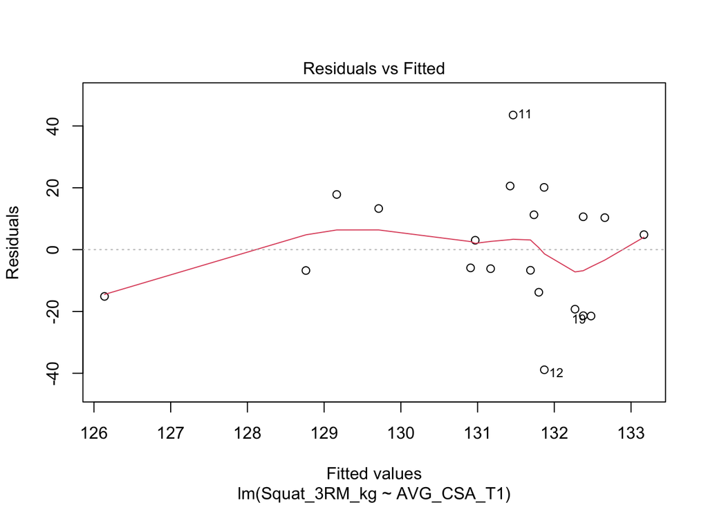

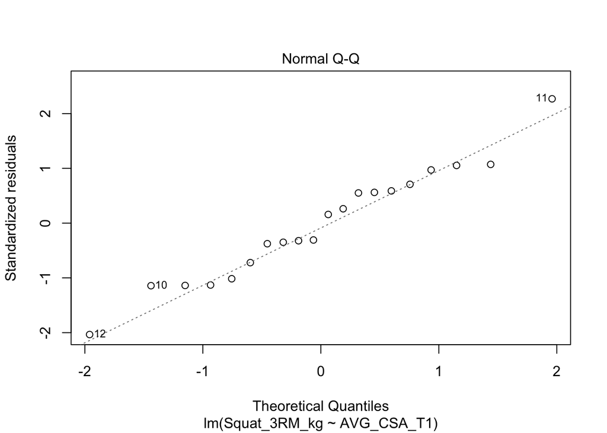

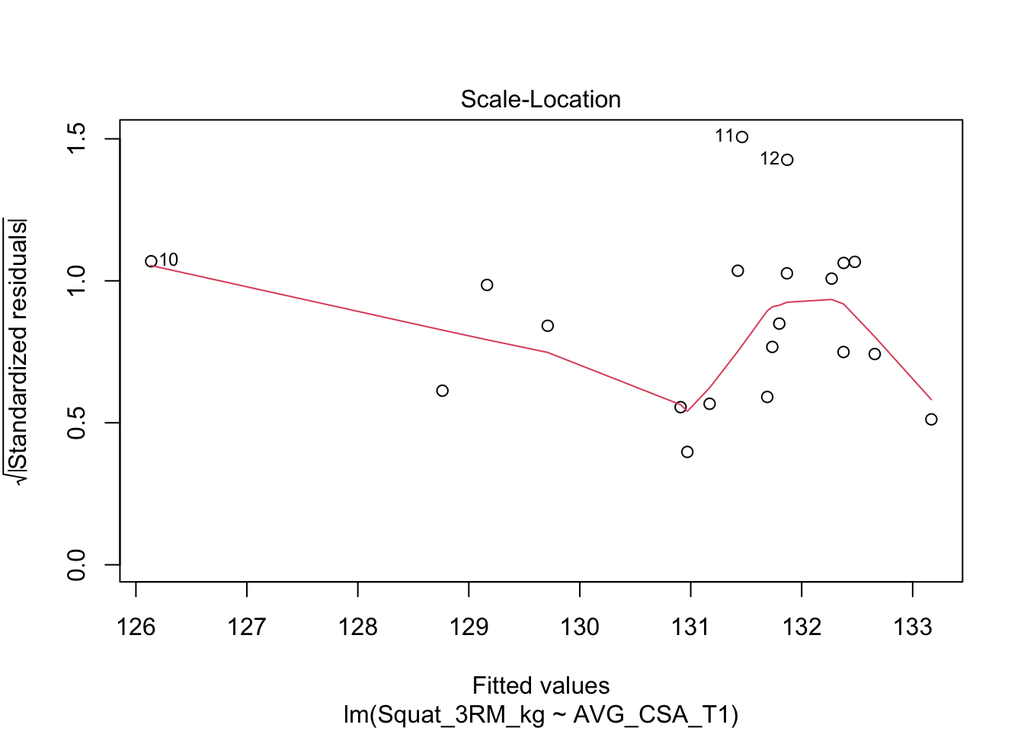

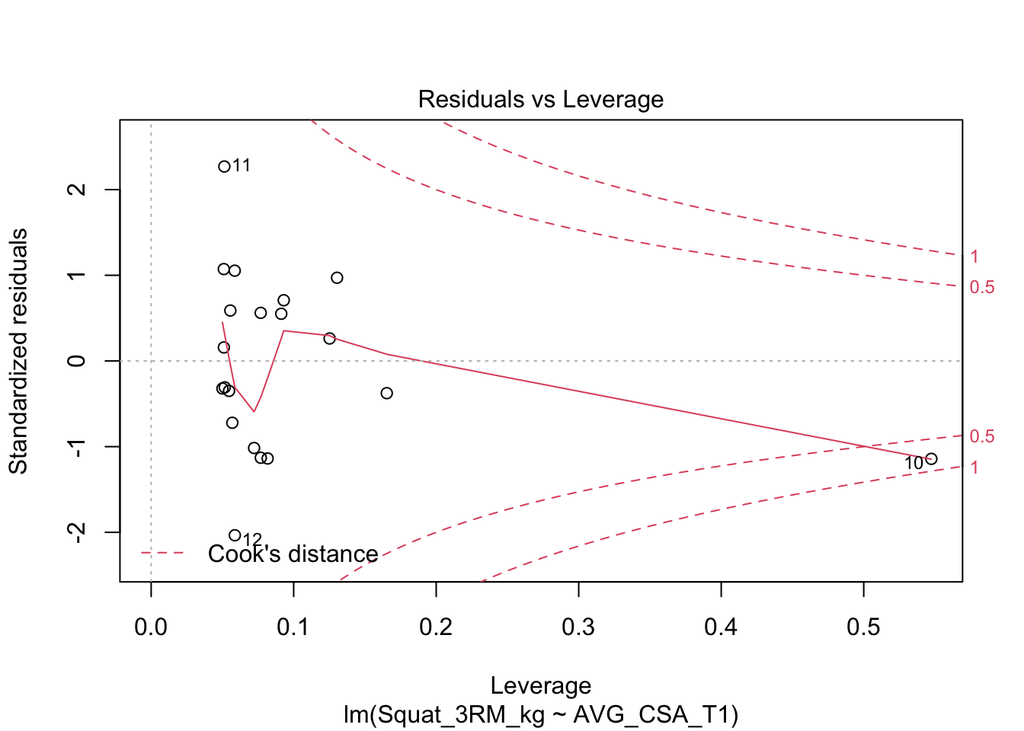

```
## Length  Class   Mode
##      0   NULL   NULL
```

```r
plot(Styrke1) %>% #plotter regresjonsmodell
  summary(Styrke1) %>%  #oppsummering av tabell
  print()
```

```r
  confint(Styrke1) %>% #legger til konfidensintervall

  print()
```

```
##                   2.5 %       97.5 %
## (Intercept) 94.64815717 1.826830e+02
## AVG_CSA_T1  -0.01242764 8.753172e-03
```